# Práctica 9 Reconstrucción filogenética

embed-resources se utiliza para que no incluya los recursos en otros archivos o carpetas

# **Ejercicio 1**

## **Leer los datos en R**

```r
library(phangorn)
mtdna <- read.phyDat('../../data/mtDNA.fasta', format = 'fasta')
glance(mtdna)
```

```
  nseq nchar unique_site_pattern parsimony_informative_sites const_sites
1   42 16603                 974                        2047       13482
```

### Note

Sería sensato reducir el conjunto de datos. ¿Qué secuencias eliminarías? Si quieres, puedes intentarlo con la función subset().

Esperaremos a construir el árbol para decidir qué secuencias eliminaríamos.Las secuencias que nos podría interesar eliminar podrían ser aquellas puntas que tengan edades con una amplitud de edad muy grande.

## **Escoger el modelo de evolución**

```r
modelos <- modelTest(mtdna, control = pml.control(trace = 0),
                     multicore = TRUE, mc.cores = 2)
```

Me describe el modelo, pudiendo sacar toda la informacion > fit <- as.pml(modelos,‘GTR+G(4)+I’) > fit

Criterio para escoger el mejor modelo: > fit <- as.pml(modelos,‘BIC’)

Cuando trabajamos en un bloque de R podemos hacer lo siguiente para que las figuras se vean más grandes que 5x5:

```r
#|fig-width: 5
#|fig-height: 10
```

## **NJ y UPGMA**

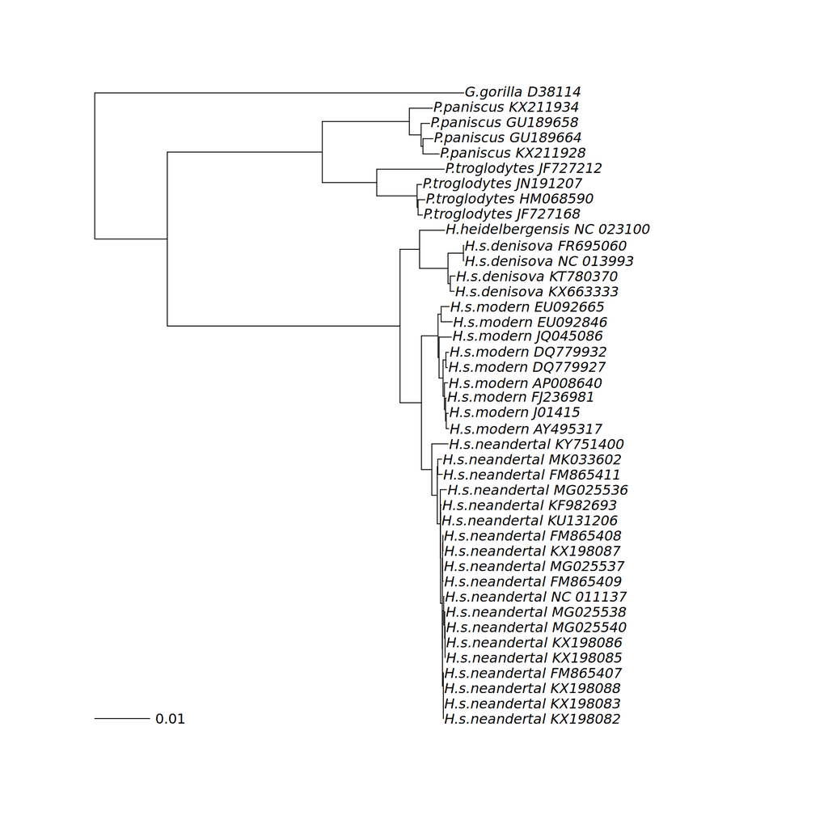

```r
mt_nj    <-    NJ(dist.dna(as.DNAbin(mtdna), model = 'TN93', gamma = 0.93))
mt_upgma <- upgma(dist.dna(as.DNAbin(mtdna), model = 'TN93', gamma = 0.93))
plot(midpoint(mt_nj))
add.scale.bar()
```

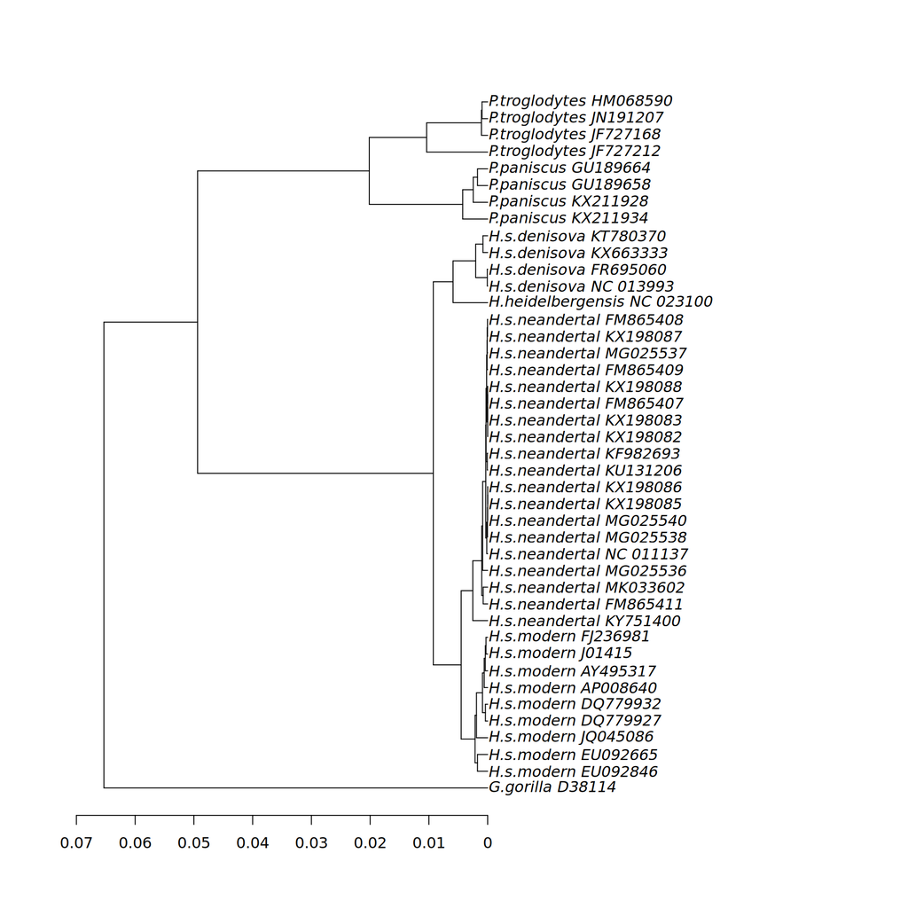

```r
plot(mt_upgma)
axisPhylo()
```

### Note

Cuando la función plot() se aplica a un objeto de clase phylo, en realidad se ejecuta la función plot.phylo(). Si quieres explorar las opciones de representación gráfica de árboles con plot(), consulta help(plot.phylo).

¿Por qué usamos midpoint() al representar gráficamente el árbol de NJ?

## Podemos enraizar el árbol

```r
enraizado <- root(mt_nj, 'G.gorilla_D38114')
```

[figure not shown]

```r
veros <- pml_bb(mtdna, model = 'GTR+G(4)+I',
                control = pml.control(trace = 0))
plot(veros)
```

[figure not shown]

```r
mt_ml <- root(veros$tree, 'G.gorilla_D38114')
plot(midpoint(mt_ml))
nodelabels()
```

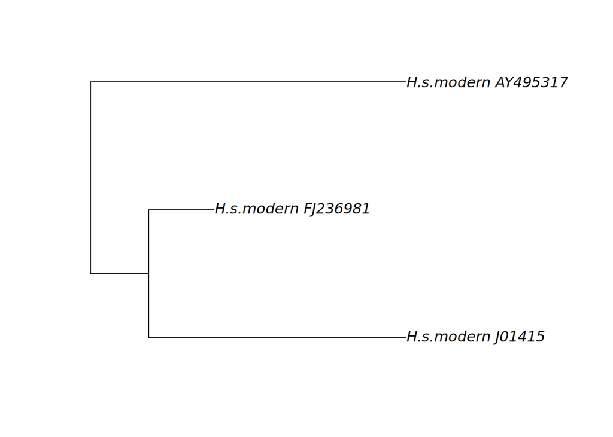

```r
homo <- extract.clade(mt_ml, 62)
plot(midpoint(homo))
```

estimate mu(): nos permite conocer si hay una tasa de evolución constante (reloj molecular) Si introducimos en el paréntesis “dates” apareceran las edades.

Trata de estimar la frecuencua de mutación mirando aquello que falta. Si en lugar de tip dates usamos note dates en algunas de estas funciones podemos dar las edades en años.

Dificultad: cuando queremos usar un vector de edades de los nodos tenemos que saber el orden en el que aparecen.

Tip dating obliga a que el árbol sea ultramétrico y que respete las edades. Las secuencias arcaicas deberían quedar más hacia el interior.

A nosotros lo que nos interesa es la relación entre humanos y chimpancés, el resto de puntas podemos añadirle valores asignados.